# Kaggle Dataset: Diagnosis of COVID-19 and its clinical spectrum

AI and Data Science supporting clinical decisions (from 28th Mar to 1st Apr)

3/30/2020

Autores e participantes do projeto:

- [Fellipe Gomes](https://github.com/gomesfellipe) (Estatístico - UFF, Cientista de Dados - FGV IBRE)
- [João Pedro Medeiros](http://lattes.cnpq.br/2533554356367029) (Estudante de Medicina - UFJF)

# Definição do Problema

Dataset do Kaggle: https://www.kaggle.com/einsteindata4u/covid19, maiores informações sobre o dataset e o desafio [neste link](https://www.kaggle.com/einsteindata4u/covid19) da competição ou [neste link](https://github.com/gomesfellipe/cod19_kaggle_einstein) do repositório deste projeto no github.

## Descrição

A descrição completa do problema pode ser obtida no repositório oficial do projeto. A finalidade deste repositório é resolver a [Task 1](https://www.kaggle.com/einsteindata4u/covid19/tasks?taskId=645) proposta para este dataset, que consistem em:

*Com base nos resultados de exames laboratoriais comumente coletados para um caso suspeito de COVID-19 durante uma visita à sala de emergência, seria possível prever o resultado do teste para SARS-Cov-2 (positivo / negativo)?*

## Objetivo

O objetivo final deste projeto será: Prever casos confirmados de COVID-19 entre casos suspeitos.

Para resolver o objetivo deste projeto duas abordagens seriam possíveis para resolver este desafio, são elas:

1. Criar um modelo heurístico utilizando regras pré-estabelecidas por médicos e especialistas da área da saúde;
2. Treinar um modelo estatístico que forma que a importância de cada atributo seja obtida de forma automática através de aplicações de metodologias apropriadas.

Devido ao curto período de tempo dedicado à construção das regras do modelo, utilizaremos a abordagem (2.) para automatizar esta tarefa.

## Premissas

Antes da manipulação dos dados, realizou-se uma revisão da literatura em conjunto com um graduando da área da saúde para ver o que já foi elucidado e pós essa revisão, algumas das premissas consideradas para a construção do modelo:

- Não ter os dados de sintomas pode tornar a tarefa mais difícil, já que os muitos parâmetros dados podem ter alterações inespecíficas, ou seja, essas podem ter como causa diversas origens tanto internas quanto externas.
- Todos os exames positivos pra outros microrganismos são critérios importantes para diagnostico (por que se a pessoa esta com influenza positivo, por exemplo, provavelmente não deve ter o corona vírus positivo a não ser que a pessoa tenha os dois. No caso de ter os dois, isso pode ser importante pra ver quem precisaria de uti);
- O paciente é encaminhado ou para regular ward ou para semi-intensive unit ou para intensive care unit pois verificou-se na base de dados que em casos positivos para SARS-Cov-2, os pacientes são encaminhados uma única vez;
- O nível de açúcar no sangue (glicemia) é um importante fator para a pessoa ir para a uti mas não é importante para o diagnostico já que a glicemia meio é um fator importante para o diagnóstico da diabetes. Contudo somente a glicemia não diagnóstica a diabetes, sendo assim necessários outros dados como o nível de hemoglobina glicada;
- Diabetes é um fator de risco, pois pacientes diabéticos descompensados possuem alta glicemia e processos inflamatórios crônicos, que dificultam a ação do sistema imune. Além disso, diabéticos parecem ter níveis receptores de angiotensina II regulados de forma a facilitar a entrada no vírus nas células (Fato que ainda deve ser estudado e elucidado) ;
- Valores dos exames foram normalizados para que a média fosse zero.

## Dados fornecidos

Os dados fornecidos parecem ser de exames específicos de microrganismos, exame de sangue e exame urina. É importante levar em consideração que nem todos os dados serão úteis para cada desafio.

Carregar pacotes, dados e funções auxiliares:

```r
knitr::opts_chunk$set(echo = TRUE, message=FALSE, warning=FALSE, result=FALSE, cache=FALSE)

library(visdat)  #kaggle error
library(funModeling) # kaggle error
library(janitor)      # clean_names
library(ggplot2)      # graficos
library(readxl)       # leitura da base
library(dplyr)        # manipulacao
library(purrr)        # programacao funcional
library(stringr)      # manipular strings
library(rsample)      # amostragem
library(recipes)      # pre processing
library(caret)        # machine learning
library(DataExplorer) # rapida analise exploratoria
library(knitr)        # print tables
library(kableExtra)   # print tables
library(doParallel)   # parallel computing
library(DMwR)         # SMOTE
library(plotROC)      # plot ROC
library(pROC)         # plot ROC

theme_set(theme_bw()) # Ttema ggplo
# Definir clusters
cl <- makeCluster(8, outfile="")
registerDoParallel(cl)
# stopCluster(cl)

dataset <- read_excel("dataset.xlsx")
```

# Resumo e analise dos dados

Nesta seção será realizada a análise exploratória da estrutura dos dados bem como desenvolver uma função para tratamento da base antes de usar como input de modelos

## Estrutura dos dados

Primeiramente veja a estrutura dos dados:

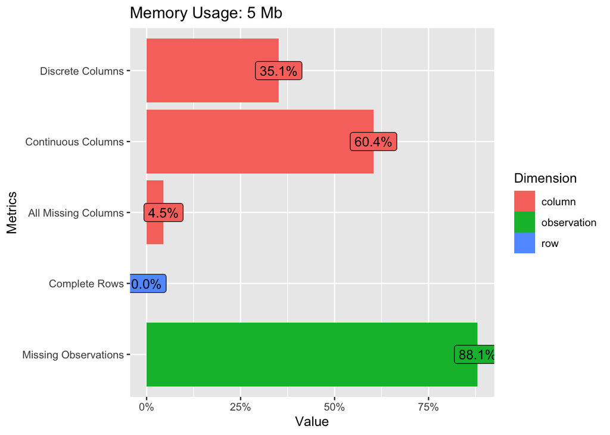

```r
plot_intro(dataset)
```

Existe uma grande quantidade de dados faltantes (incluindo colunas completamente vazias) e isso é uma característica que influenciará diretamente na escolha do modelo adotado.

Veja um outro panorama geral dos dados:

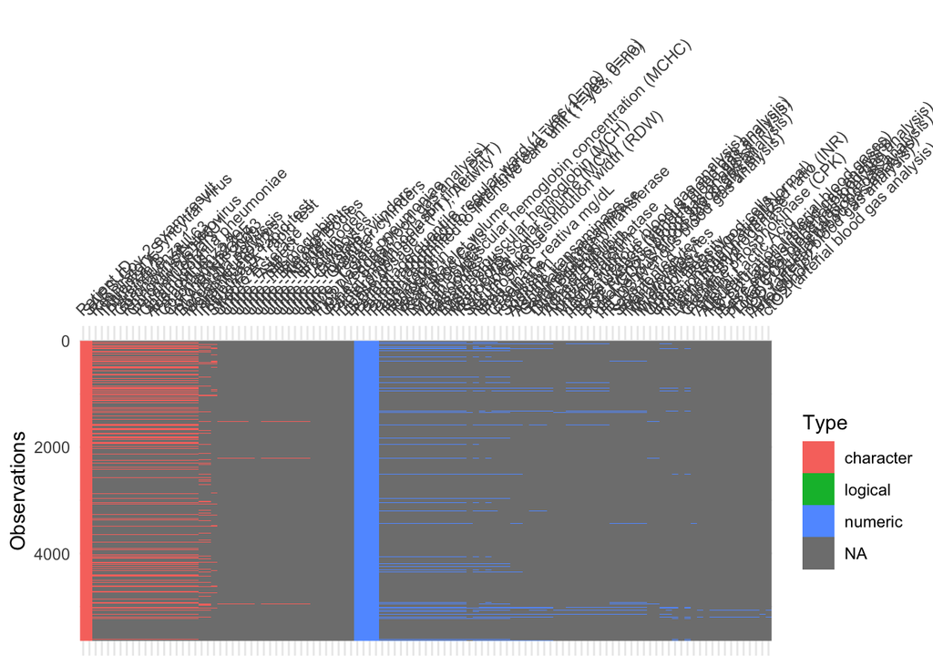

```r
visdat::vis_dat(dataset) # problema no kaggle
```

A tabela abaixo apresenta as quantidades e porcentagens de dados faltantes e zeros no dataset:

```r
# problema no kaggle
dataset %>%
  funModeling::df_status(print_results = F) %>%
  arrange(-p_zeros) %>%
  kable() %>%
  kable_styling() %>%
  scroll_box(width = "500px", height = "200px")
```

| variable | q_zeros | p_zeros | q_na | p_na | q_inf | p_inf | type | unique |
| --- | --- | --- | --- | --- | --- | --- | --- | --- |
| Patient addmited to intensive care unit (1=yes, 0=no) | 5603 | 99.27 | 0 | 0.00 | 0 | 0 | numeric | 2 |
| Patient addmited to semi-intensive unit (1=yes, 0=no) | 5594 | 99.11 | 0 | 0.00 | 0 | 0 | numeric | 2 |
| Patient addmited to regular ward (1=yes, 0=no) | 5565 | 98.60 | 0 | 0.00 | 0 | 0 | numeric | 2 |
| Patient age quantile | 334 | 5.92 | 0 | 0.00 | 0 | 0 | numeric | 20 |
| Myeloblasts | 97 | 1.72 | 5547 | 98.28 | 0 | 0 | numeric | 1 |
| Lipase dosage | 5 | 0.09 | 5636 | 99.86 | 0 | 0 | logical | 2 |
| Fio2 (venous blood gas analysis) | 1 | 0.02 | 5643 | 99.98 | 0 | 0 | logical | 1 |
| Patient ID | 0 | 0.00 | 0 | 0.00 | 0 | 0 | character | 5644 |
| SARS-Cov-2 exam result | 0 | 0.00 | 0 | 0.00 | 0 | 0 | character | 2 |
| Hematocrit | 0 | 0.00 | 5041 | 89.32 | 0 | 0 | numeric | 176 |
| Hemoglobin | 0 | 0.00 | 5041 | 89.32 | 0 | 0 | numeric | 84 |
| Platelets | 0 | 0.00 | 5042 | 89.33 | 0 | 0 | numeric | 249 |
| Mean platelet volume | 0 | 0.00 | 5045 | 89.39 | 0 | 0 | numeric | 48 |
| Red blood Cells | 0 | 0.00 | 5042 | 89.33 | 0 | 0 | numeric | 211 |
| Lymphocytes | 0 | 0.00 | 5042 | 89.33 | 0 | 0 | numeric | 318 |
| Mean corpuscular hemoglobin concentration (MCHC) | 0 | 0.00 | 5042 | 89.33 | 0 | 0 | numeric | 57 |
| Leukocytes | 0 | 0.00 | 5042 | 89.33 | 0 | 0 | numeric | 475 |
| Basophils | 0 | 0.00 | 5042 | 89.33 | 0 | 0 | numeric | 17 |
| Mean corpuscular hemoglobin (MCH) | 0 | 0.00 | 5042 | 89.33 | 0 | 0 | numeric | 91 |
| Eosinophils | 0 | 0.00 | 5042 | 89.33 | 0 | 0 | numeric | 86 |
| Mean corpuscular volume (MCV) | 0 | 0.00 | 5042 | 89.33 | 0 | 0 | numeric | 190 |
| Monocytes | 0 | 0.00 | 5043 | 89.35 | 0 | 0 | numeric | 146 |
| Red blood cell distribution width (RDW) | 0 | 0.00 | 5042 | 89.33 | 0 | 0 | numeric | 61 |
| Serum Glucose | 0 | 0.00 | 5436 | 96.31 | 0 | 0 | numeric | 71 |
| Respiratory Syncytial Virus | 0 | 0.00 | 4290 | 76.01 | 0 | 0 | character | 2 |
| Influenza A | 0 | 0.00 | 4290 | 76.01 | 0 | 0 | character | 2 |
| Influenza B | 0 | 0.00 | 4290 | 76.01 | 0 | 0 | character | 2 |
| Parainfluenza 1 | 0 | 0.00 | 4292 | 76.05 | 0 | 0 | character | 2 |
| CoronavirusNL63 | 0 | 0.00 | 4292 | 76.05 | 0 | 0 | character | 2 |
| Rhinovirus/Enterovirus | 0 | 0.00 | 4292 | 76.05 | 0 | 0 | character | 2 |

[output cut: 81 more lines]

## Visualizações

Após obter a análise geral dos dados, será utilizado o pacote `DataExplorer` para se obter um resumo rápido mais detalhado dos dados disponíveis antes de qualquer tratamento dos dados:

```r
# criar relatorio rapido
create_report(janitor::clean_names(dataset), y = 'sars_cov_2_exam_result',
              output_file = "report.html")
```

Este relatório pode ser lido [neste link](https://github.com/gomesfellipe/cod19_kaggle_einstein/blob/master/report.html)

## Tratamento dos dados

Antes de calcular estatísticas e ajustar modelos é necessário fazer um tratamento nos dados. Além de remover todas colunas e linhas 100% vazias é necessário converter os dados corretamente para possibilitar as analises utilizando R.

Embora [existam estudos que comentem](https://www.ajronline.org/doi/pdf/10.2214/AJR.20.22959) sobre o uso dos atributos *D-Dimer* e *Urine sugar* (que denota atividade renal/ diabetes) para caracterizar um caso de COVID-19, não utilizaremos pois não existem dados de treino disponíveis.

Além disso, existem outros atributos numéricos que possuem mais de 90% de dados faltantes porém será necessário cautela antes de aplicar qualquer método de imputação de dados pois, por exemplo, incluir o valor `0` nos leucócitos iria colocar aquele paciente como um leucopênico, como se ele nao tivesse leucócitos.

Após a análise exploratória definiu-se os seguintes tratamentos dos dados:

- Padronizar o nome das colunas
  - Converter todas categóricas para caractere
  - Remover variáveis target da outra tarefa
  - Remover colunas onde todas as linhas sao vazias
  - Remover linhas onde todas as colunas sao vazias
  - Converter para numérico
  - Converter para categórico ordinal
  - Converter “nao realizado” para NA
  - Converter logico para numérico
  - Remover variáveis numéricas com cardinalidade menor do que 10
  - Arrumar categorias com cardinalidade 1
  - Remover categoria com 1 nível

Obs.: Não foram criadas variáveis Dummies pois incluiria viés em nosso dataset. Além disso os dados numéricos ausentes não foram substituídos por 0 pois indicaria que um paciente estaria com os parâmetros ok enquanto isso pode não ser verdade.

```r
treatment <- function(dataset){

  # Converter o nome das colunas e converter tudas categoricas para character
dataset <-
  dataset %>%
  mutate_if(is.factor, as.character) %>%
  janitor::clean_names() %>%
  select(-one_of("patient_id"))

# Remover variaveis target da outra tarefa -----
dataset <-
  dataset %>%
  select(-one_of('patient_addmited_to_regular_ward_1_yes_0_no',
                 'patient_addmited_to_semi_intensive_unit_1_yes_0_no',
                 'patient_addmited_to_intensive_care_unit_1_yes_0_no'))

# Remover colunas onde todas as linhas sao vazias -----
# Ninguem fez o exame
all_row_na <-
  dataset %>%
  select_if(~sum(is.na(.x)) == nrow(dataset)) %>%
  colnames()

dataset <- dataset %>% select(-one_of(all_row_na))

# Remover linhas onde todas as colunas sao vazias -----
# O individuo nao fez nenhum exame
all_cols_na <-
  dataset %>%
  select_if(~! sum(!is.na(.x)) == nrow(dataset)) %>%
  { apply(., 1, function(x){sum(is.na(x))}) != ncol(.) } %>%
  which()
dataset <- dataset %>% slice(all_cols_na)

# Converter para numerico -----
dataset <- dataset %>%
  mutate_at('urine_p_h', ~as.numeric(ifelse(.x == "Não Realizado", NA, .x)))

# Converter para categorico ordinal -----
urine_leuk_levels <-
  table(dataset$urine_leukocytes) %>% names() %>%
  str_replace("<1000", "0") %>% as.numeric() %>% sort()

dataset <- dataset %>%
  mutate(urine_leukocytes = str_replace(urine_leukocytes, "<1000", "0") %>%
           as.factor() %>% ordered(levels = urine_leuk_levels) %>% as.numeric())

# Converter "nao realizado" para NA -----
dataset <-
  dataset %>%
  mutate_at(c('strepto_a',
              'urine_esterase',
              'urine_hemoglobin',
              'urine_bile_pigments',
              'urine_ketone_bodies',
              'urine_protein'),
            ~ ifelse(.x == 'not_done', NA, .x))

# Converter logico para numerico -----
dataset <- dataset %>% mutate_if(is.logical, as.numeric)

# Remover variaveis numericas com cardinalidade menor do que 10 -----
num_card_mq10 <-
  which( dataset %>% select_if(is.numeric) %>% map_dbl(~length(unique(.x))) < 10) %>%
  names()
dataset <- dataset %>% select(-one_of(num_card_mq10))

# Nao substituir numericos faltantes por 0 pois estes valores possuem significado

# Arrumar categorias com cardinalidade 1 -----
dataset <- dataset %>%
  mutate(urine_crystals = if_else(urine_crystals != "Ausentes", "other", "Ausentes"))

dataset <- dataset %>%
  mutate(urine_aspect = if_else(urine_aspect != "clear", "other", "clear"))

dataset <- dataset %>%
  mutate(urine_color = if_else(urine_color != "light_yellow", "other", "light_yellow"))

dataset <- dataset %>% mutate_if(is.character, as.factor)

# Remover categoria com 1 nivel -----
cat_um_nv <-
  dataset %>%
  select_if(~!is.numeric(.x)) %>%
  map_lgl(~length(levels(.x)) == 1) %>% which() %>%
  names()

dataset <- dataset %>% select(-one_of(cat_um_nv))


# todo: conferir inf_a_h1n1_2009 e influenza_b

return(dataset)

}
```

A estrutura dos dados após aplicar a função e tratamento:

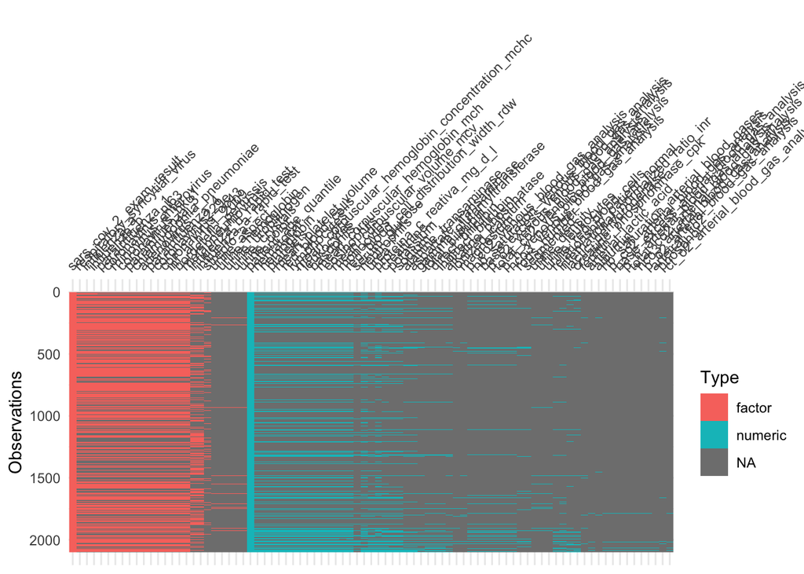

```r
dataset <- treatment(dataset)
visdat::vis_dat(dataset) # problema no kaggle!
```

# Preparar dados

Nesta seção serão desenvolvidos diferentes opções de datasets pré-processados para treino e teste utilizando principalmente os pacotes `caret` e `recipes`

## Preparar recipientes

Dois recipientes serão preparados para desenvolver diferentes conjuro de treino e teste para o modelo: primeiro recipiente com transformação `YeoJojnson` e `NearZeroVar` e o segundo recipiente incluindo input de dados ausentes utilizando 3 vizinhos mais próximos.

```r
set.seed(1) # reprodutibilidade
dataset_initial_split  <- initial_split(dataset,
                                        strata = sars_cov_2_exam_result,
                                        prop = 0.9)

recipe_ini <-
  recipe(sars_cov_2_exam_result ~ ., data = training(dataset_initial_split)) %>%
  step_YeoJohnson(all_numeric()) %>%
  step_nzv(-all_outcomes())

recipe_knn <-
  recipe_ini %>%
  step_knnimpute(all_predictors(), neighbors = 3)
```

## Preparar dados de treino e teste

Primeiramente utilizar a função `bake()` para utilizar os recipientes para obter os dados pré-processados:

```r
train_ini <- bake(prep(recipe_ini), training(dataset_initial_split))
train_knn <- bake(prep(recipe_knn), training(dataset_initial_split))
```

Note que existe um forte desbalanceamento nos dados :

```r
table(train_ini$sars_cov_2_exam_result)
```

```
##
## negative positive
##     1730      161
```

Sendo assim, serão aplicados os métodos `SMOTE` e `downSample` de pré-processamento para balancear os dados:

```r
train_ini_down <-
  downSample(y = train_ini %>% pull(sars_cov_2_exam_result),
             x = train_ini %>% select(-sars_cov_2_exam_result),
             yname = "sars_cov_2_exam_result") %>%
  as_tibble()

train_knn_down <-
  downSample(y = train_knn %>% pull(sars_cov_2_exam_result),
             x = train_knn %>% select(-sars_cov_2_exam_result),
             yname = "sars_cov_2_exam_result") %>%
  as_tibble()

train_ini_smote <-
  SMOTE(sars_cov_2_exam_result ~ ., data  = as.data.frame(train_ini)) %>%
  as_tibble()

train_knn_smote <-
  SMOTE(sars_cov_2_exam_result ~ ., data  = as.data.frame(train_knn)) %>%
  as_tibble()
```

Dessa forma existem 6 datasets de treino para avaliar qual o pré-processamento que melhora substancialmente a qualidade do ajuste do modelo e para isso também será necessário aplicar os recipientes nos dataset de teste:

```r
test_ini <- bake(prep(recipe_ini), testing(dataset_initial_split))
test_knn <- bake(prep(recipe_knn), testing(dataset_initial_split))
```

Note que não se faz necessário criar mais datasets de test para os processos de balanceamento.

# Avaliar algoritmos

Nesta seção serão avaliados os resultados dos modelos ajustados para cada base de treino preparada na seção anterior

## Seleção de modelos

O modelo *Recursive Feature Elimination* (RFE) foi o selecionado para resolver a Task pois existe uma grande quantidade de atributos disponíveis para ajustar um modelo para prever casos de COVID-19, espera-se que um modelo com recursos para seleção de atributos tenha um bom desempenho. Além disso existe grande quantidade de dados faltantes e dados muito esparsos, o que também exige a adoção de um modelo que não faça suposições sobre o formato dos dados.

A métrica para regular a qualidade do ajuste selecionada foi a `ROC` pois a `Acuracy` não é indicada para este contexto pois existe uma preocupação é maximizar tanto a `Sens` quanto a `Spec`. Os tamanhos de amostra que serão testados serão: 5, 7, 10, 15, 20, 25

```r
set.seed(10)

treebagFuncs$summary <- twoClassSummary # AUC
ctrl <- rfeControl(method = "repeatedcv",
                   number = 5,
                   repeats = 3,
                   verbose = T,
                   functions = treebagFuncs)

custom_rfe <- function(x){
  rfe(x %>% select(-sars_cov_2_exam_result),
      x %>% pull(sars_cov_2_exam_result),
      sizes = c(5, 7, 10, 15, 20, 25),
      metric="ROC",
      rfeControl = ctrl,
      na.action = na.pass)
}
```

Com todos os parâmetros definidos vamos aos ajustes:

```r
rfe_ini       <- custom_rfe(train_ini)
rfe_ini_down  <- custom_rfe(train_ini_down)
rfe_ini_smote <- custom_rfe(train_ini_smote)
rfe_knn       <- custom_rfe(train_knn)
rfe_knn_down  <- custom_rfe(train_knn_down)
rfe_knn_smote <- custom_rfe(train_knn_smote)
```

## Avaliar qualidade do ajuste dos modelos

Confira a Curva ROC e medida AUC de cada modelo:

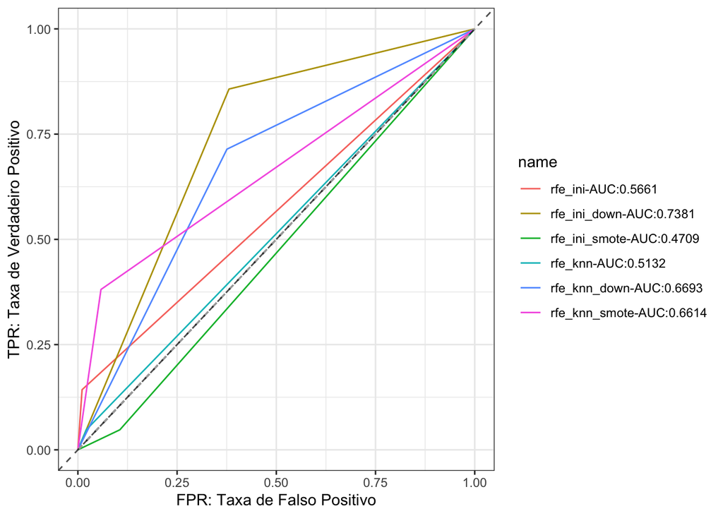

```r
to_roc <-
  tibble(
    original = testing(dataset_initial_split) %>%
      pull(sars_cov_2_exam_result) %>% {if_else(. == "negative", 0, 1)}
    ,
    rfe_ini = predict(rfe_ini, newdata = test_ini) %>%
      pull(pred) %>% {if_else(. == "negative", 0, 1)}
    ,
    rfe_ini_down = predict(rfe_ini_down, newdata = test_ini) %>%
      pull(pred) %>% {if_else(. == "negative", 0, 1)}
    ,
    rfe_ini_smote = predict(rfe_ini_smote, newdata = test_ini) %>%
      pull(pred) %>% {if_else(. == "negative", 0, 1)}
    ,
    rfe_knn = predict(rfe_knn, newdata = test_knn) %>%
      pull(pred) %>% {if_else(. == "negative", 0, 1)}
    ,
    rfe_knn_down = predict(rfe_knn_down, newdata = test_knn) %>%
      pull(pred) %>% {if_else(. == "negative", 0, 1)}
    ,
    rfe_knn_smote = predict(rfe_knn_smote, newdata = test_knn) %>%
      pull(pred) %>% {if_else(. == "negative", 0, 1)}

  )

rocobj <- pROC::roc(original ~. , data = to_roc)

names(rocobj) <-
  map2_chr(rocobj,
           c('rfe_ini','rfe_ini_down', 'rfe_ini_smote',
             'rfe_knn', 'rfe_knn_down', 'rfe_knn_smote'),
           ~ paste0(.y, "-AUC:", round(as.numeric(auc(.x)), 4)))

ggroc(rocobj, legacy.axes = T) + xlab("FPR") + ylab("TPR") +
  geom_segment(aes(x = 0, xend = 1, y = 0, yend = 1), color="darkgrey", linetype="dashed")+
  geom_abline(slope = 1, linetype = 2, alpha = .7)+
  labs(x = "FPR: Taxa de Falso Positivo", y = "TPR: Taxa de Verdadeiro Positivo")
```

Note que o modelo RFE sem input de dados com balanceamento `downSample` foi o modelo que apresentou maior AUC, o que indica que ele teve o melhor desempenho baseado nessa medida resumo, dentre os modelos ajustados.

Porém como trata-se de um problema envolvendo dados desbalanceados, é necessário conferir outras métricas como a sensibilidade e a especificidade do modelo. Abaixo um resumo das estatísticas dos ajustes de cada modelo:

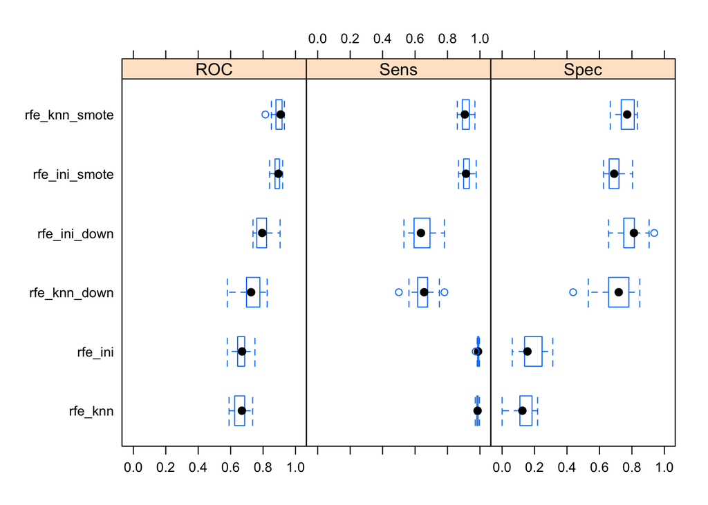

```r
resamp <- resamples(list(rfe_ini = rfe_ini,
                         rfe_ini_down = rfe_ini_down,
                         rfe_ini_smote = rfe_ini_smote,
                         rfe_knn = rfe_knn,
                         rfe_knn_down = rfe_knn_down,
                         rfe_knn_smote = rfe_knn_smote))
bwplot(resamp)
```

Note que o pré processamento que apresentou os melhor resultados `ROC`, `Sens` e `Spec` no geral foi o RFE com input knn e ajuste SMOTE para balanceamento.

## Modelo final

Estes dois modelos comentados serão selecionados para uma análise mais detalhada nos dados de teste. Veja a matriz de confusão destes dois modelos nos dados de teste:

1. RFE sem input de dados faltantes com balanceamento `downSample`:

Nos dados de treino:

```r
rfe_ini_down
```

```
##
## Recursive feature selection
##
## Outer resampling method: Cross-Validated (5 fold, repeated 3 times)
##
## Resampling performance over subset size:
##
##  Variables    ROC   Sens   Spec   ROCSD  SensSD  SpecSD Selected
##          5 0.7763 0.6502 0.7514 0.05705 0.08703 0.07672
##          7 0.7938 0.6730 0.7766 0.04806 0.08593 0.05530
##         10 0.7975 0.6666 0.7764 0.04694 0.08056 0.05271
##         15 0.7940 0.6585 0.7784 0.04520 0.06930 0.07740
##         20 0.7912 0.6689 0.7887 0.04899 0.05978 0.05929
##         25 0.8004 0.6480 0.7972 0.04942 0.06961 0.07209        *
##         70 0.7905 0.6647 0.7701 0.05238 0.07546 0.06418
##
## The top 5 variables (out of 25):
##    patient_age_quantile, leukocytes, platelets, eosinophils, proteina_c_reativa_mg_d_l
```

Nos dados de teste:

```r
confusionMatrix(
  predict(rfe_ini_down, newdata = test_ini) %>% pull(pred),
  test_ini %>% pull(sars_cov_2_exam_result)
)
```

```
## Confusion Matrix and Statistics
##
##           Reference
## Prediction negative positive
##   negative      117        3
##   positive       72       18
##
##                Accuracy : 0.6429
##                  95% CI : (0.574, 0.7076)
##     No Information Rate : 0.9
##     P-Value [Acc > NIR] : 1
##
##                   Kappa : 0.1935
##
##  Mcnemar's Test P-Value : 4.096e-15
##
##             Sensitivity : 0.6190
##             Specificity : 0.8571
##          Pos Pred Value : 0.9750
##          Neg Pred Value : 0.2000
##              Prevalence : 0.9000
##          Detection Rate : 0.5571
##    Detection Prevalence : 0.5714
##       Balanced Accuracy : 0.7381
##
##        'Positive' Class : negative
##
```

2. RFE com input de dados faltante e balanceamento `SMOTE`

Nos dados de treino:

```r
rfe_knn_smote
```

```
##
## Recursive feature selection
##
## Outer resampling method: Cross-Validated (5 fold, repeated 3 times)
##
## Resampling performance over subset size:
##
##  Variables    ROC   Sens   Spec   ROCSD  SensSD  SpecSD Selected
##          5 0.8834 0.9203 0.7467 0.02914 0.03077 0.04077
##          7 0.8859 0.9140 0.7597 0.02901 0.03303 0.04735
##         10 0.8882 0.9088 0.7584 0.02990 0.03572 0.03712
##         15 0.8911 0.9094 0.7535 0.03294 0.03078 0.03901
##         20 0.8951 0.9145 0.7625 0.03449 0.03154 0.04912
##         25 0.8954 0.9146 0.7701 0.03237 0.02972 0.05009        *
##         70 0.8935 0.9114 0.7673 0.03241 0.03385 0.03849
##
## The top 5 variables (out of 25):
##    leukocytes, arteiral_fio2, platelets, creatinine, mean_platelet_volume
```

Nos dados de teste:

```r
confusionMatrix(
  predict(rfe_knn_smote, newdata = test_knn) %>% pull(pred),
  test_knn %>% pull(sars_cov_2_exam_result)
)
```

```
## Confusion Matrix and Statistics
##
##           Reference
## Prediction negative positive
##   negative      178       13
##   positive       11        8
##
##                Accuracy : 0.8857
##                  95% CI : (0.8347, 0.9254)
##     No Information Rate : 0.9
##     P-Value [Acc > NIR] : 0.7928
##
##                   Kappa : 0.337
##
##  Mcnemar's Test P-Value : 0.8383
##
##             Sensitivity : 0.9418
##             Specificity : 0.3810
##          Pos Pred Value : 0.9319
##          Neg Pred Value : 0.4211
##              Prevalence : 0.9000
##          Detection Rate : 0.8476
##    Detection Prevalence : 0.9095
##       Balanced Accuracy : 0.6614
##
##        'Positive' Class : negative
##
```

Note que cada modelo se comportou melhor em um caso. O modelo 1 funcionou melhor para prever os casos de COVID-19 que realmente eram verdade enquanto que o modelo 2 conseguiu uma menor taxa de falsos positivos, sendo mais sensível.

O modelo final selecionando será o 2 (RFE com input knn e balanceamento SMOTE). Veja um gráfico que exibe o melhor k para ajustar o modelo:

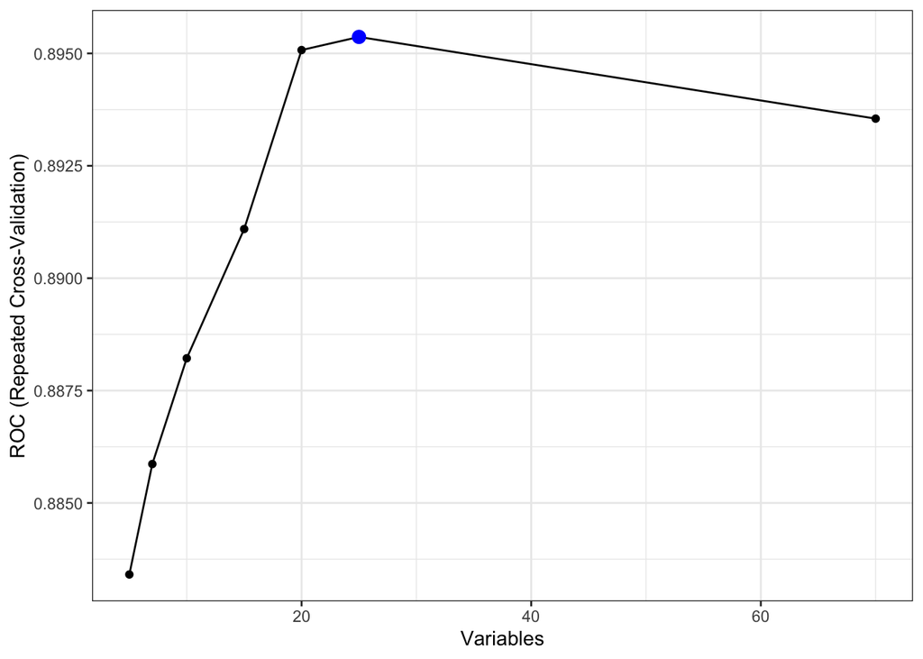

```r
ggplot(rfe_knn_smote)
```

Por fim, os atributos selecionados para melhor prever COVID-19 segundo o modelo foram: leukocytes, arteiral_fio2, platelets, creatinine, mean_platelet_volume, magnesium, patient_age_quantile, total_co2_arterial_blood_gas_analysis, eosinophils, p_o2_venous_blood_gas_analysis, hco3_arterial_blood_gas_analysis, urine_density, phosphor, ferritin, p_h_venous_blood_gas_analysis, albumin, p_co2_arterial_blood_gas_analysis, arterial_lactic_acid, relationship_patient_normal, hb_saturation_venous_blood_gas_analysis, monocytes, lactic_dehydrogenase, base_excess_venous_blood_gas_analysis, hematocrit, base_excess_arterial_blood_gas_analysis

# Conclusão e próximos passos

Neste projeto não estavam disponíveis variáveis de sintomas e muitos dados referentes a gasometria estavam faltantes. Devido ao fato que sem sintomas certos parâmetros inflamatórios se tornam inespecíficos, podendo ser referência para diversas doenças e que dados gasométricos podem inferir sintomas respiratórios e também a condição fisiológica do paciente, a falta desses é de extrema importância e poderia ajudar no ajuste do modelo melhorando-o.

Além disso, ficam outras sugestões de passos futuros para melhorar a qualidade do ajuste de um modelo para estes dados:

- Aumentar número de vizinhos
  - Testar outros métodos de balanceamento
  - Utilizar as variáveis encontradas para ajustar novos modelos

# Referências

- Valores de referências para exames de urina e sangue: https://www.msdmanuals.com/pt-pt/profissional/ap%C3%AAndices/valores-laboratoriais-normais/exames-de-urina-valores-normais
  - https://www.ncbi.nlm.nih.gov/pmc/articles/PMC7081812/pdf/clinmed-20-2-124.pdf
  - https://www.ajronline.org/doi/pdf/10.2214/AJR.20.22959
  - https://www.bmj.com/content/bmj/368/bmj.m1091.full.pdf
  - https://respiratory-research.biomedcentral.com/track/pdf/10.1186/s12931-020-01338-8
  - https://www.ajronline.org/doi/pdf/10.2214/AJR.20.22959